# Legends

Author

David

## 1 Basic Box Plot

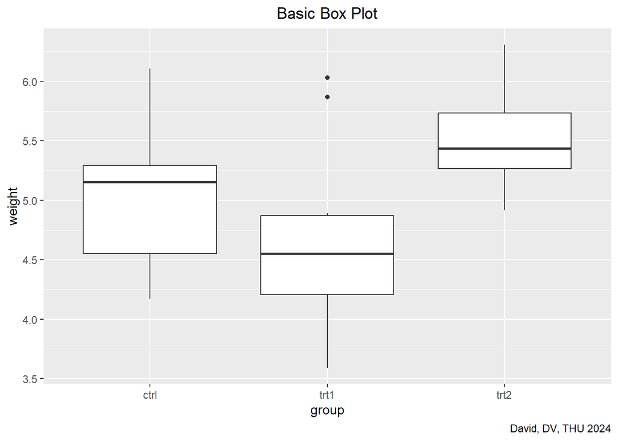

```r
library(ggplot2)
ggplot(PlantGrowth, aes(x = group, y = weight)) +
  geom_boxplot() +
  labs(title = 'Basic Box Plot',
       caption = 'David, DV, THU 2024') +
  theme(plot.title = element_text(hjust = 0.5))
```

## 2 Add Legend

- `library(gridExtra)`: Load `gridExtra` from library
- `fill`: To fill the boxplot with colors and add a legend to inform the color
- `color`: To color the border of boxplot and add a legend to inform the color
- `grid.arrange()`: To arrange multiple boxplot
  - `ncol`: number input of column in one row
- `top`: To add a title in a arrange of boxplot
- `bottom`: To add a caption in a arrange of boxplot

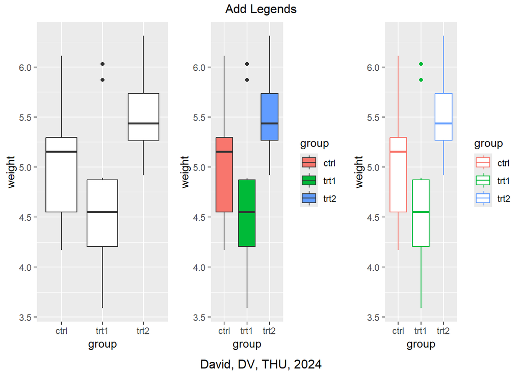

```r
library(gridExtra)

d1 <- ggplot(PlantGrowth, aes(x = group, y = weight)) +
  geom_boxplot()
d2 <- ggplot(PlantGrowth, aes(x = group, y = weight, fill = group)) +
  geom_boxplot()
d3 <- ggplot(PlantGrowth, aes(x = group, y = weight, color = group)) +
  geom_boxplot()

grid.arrange(d1, d2, d3, ncol = 3, top = 'Add Legends', bottom = 'David, DV, THU, 2024')
```

## 3 Remove The Legend

`guides(fill = 'none')`: To remove the legend

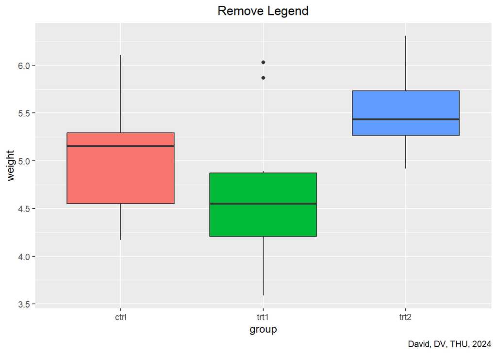

```r
ggplot(PlantGrowth, aes(x = group, y = weight, fill = group)) +
  geom_boxplot() +
  guides(fill = 'none') +
  labs(caption = 'David, DV, THU, 2024') +
  ggtitle('Remove Legend') +
  theme(plot.title = element_text(hjust = 0.5))
```

## 4 Change The Color of The Legend

- `scale_fill_brewer(palette= "Pastel2")`: Change the color fill of the boxplot to `Pastel2`
- `ggtitle()`: Add a title to the boxplot

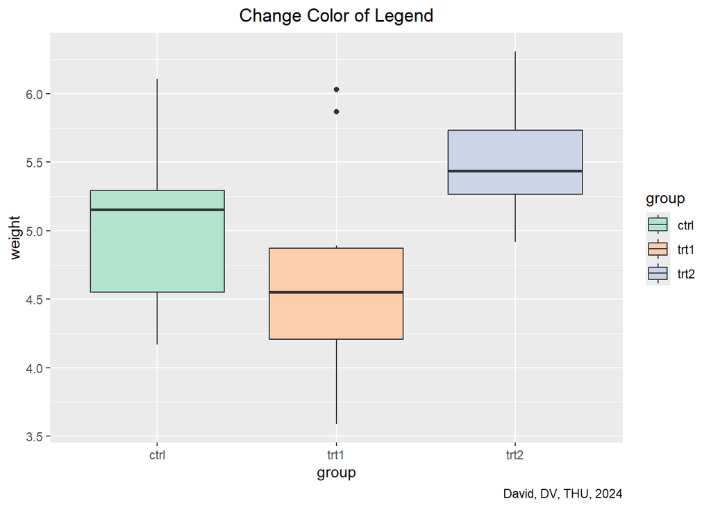

```r
ggplot(PlantGrowth, aes(x = group, y = weight, fill = group)) +
  geom_boxplot() +
  scale_fill_brewer(palette = "Pastel2") +
  ggtitle('Change Color of Legend') +
  theme(plot.title = element_text(hjust=0.5)) +
  labs(caption = 'David, DV, THU, 2024')
```

## 5 Change The Position of The Legend

- `theme(legend.position = )`: To move the position of the legend
  - `top`: To move the legend to the top of the boxplot
  - `bottom`: To move the legend to the bottom of the boxplot
  - `right`: To move the legend to the right of the boxplot
  - `left`: To move the legend to the left of the boxplot

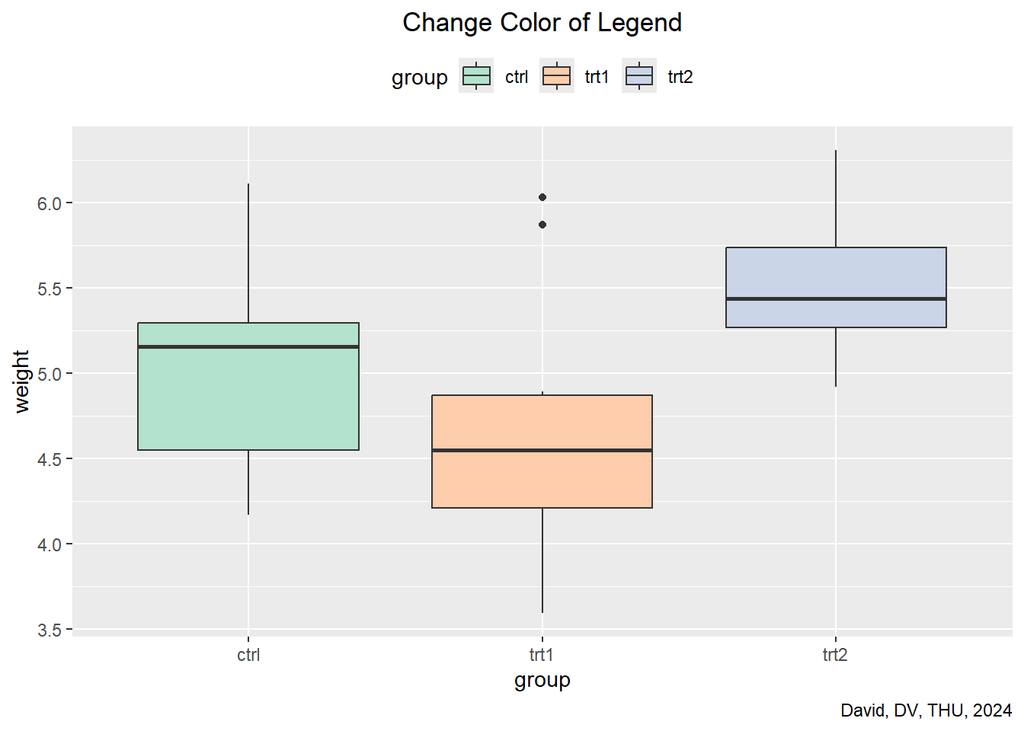

```r
ggplot(PlantGrowth, aes(x = group, y = weight, fill = group)) +
  geom_boxplot() +
  scale_fill_brewer(palette = "Pastel2") +
  ggtitle('Change Color of Legend') +
  theme(plot.title = element_text(hjust=0.5),
        legend.position = 'top') +
  labs(caption = 'David, DV, THU, 2024')
```

## 6 Practice

Practice changing color of the legend and change the position of the legend.

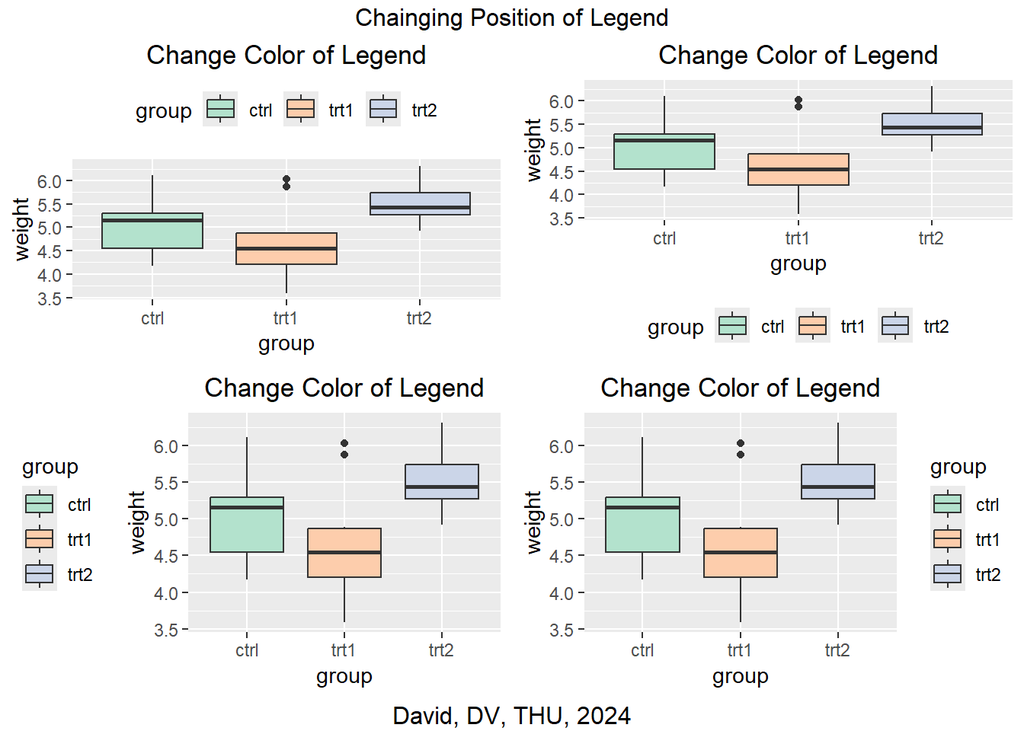

```r
d1 <- ggplot(PlantGrowth, aes(x = group, y = weight, fill = group)) +
  geom_boxplot() +
  scale_fill_brewer(palette = "Pastel2") +
  ggtitle('Change Color of Legend') +
  theme(plot.title = element_text(hjust=0.5),
        legend.position = 'top')
d2 <- d1 + theme(legend.position = 'bottom')
d3 <- d1 + theme(legend.position = 'left')
d4 <- d1 + theme(legend.position = 'right')

grid.arrange(d1, d2, d3, d4, ncol=2,
             top='Chainging Position of Legend', bottom = 'David, DV, THU, 2024')
```

## 7 Change Legend Position

- `theme(legend.position = c())`: Change the legend position in to the specific coordinate in the boxplot graph.
- `theme(element_rect(fill = 'yellow', color = 'red'))`: Change the color of the legend and change the border color of the legend

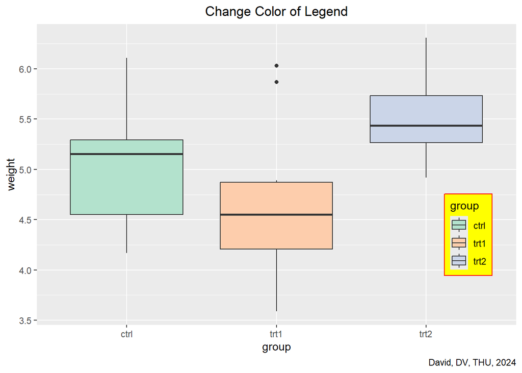

```r
ggplot(PlantGrowth, aes(x = group, y = weight, fill = group)) +
  geom_boxplot() +
  scale_fill_brewer(palette = "Pastel2") +
  ggtitle('Change Color of Legend') +
  theme(plot.title = element_text(hjust=0.5),
        legend.position = c(.9, .3),
        legend.background = element_rect(fill = 'yellow', color = 'red')) +
  labs(caption = "David, DV, THU, 2024")
```

## 8 Change the Border of Legend

- `theme(legend.background = element_rect())`: To change the background color of legend or border color of the legend
  - `fill =`: To set a color to the background of the legend
  - `color =`: To set a border color to the legend

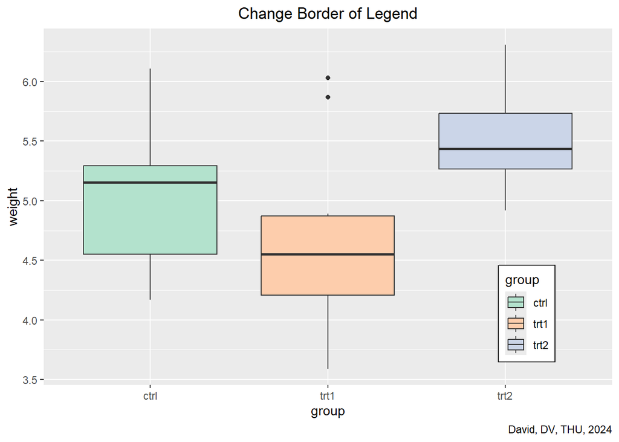

```r
ggplot(PlantGrowth, aes(x = group, y = weight, fill = group)) +
  geom_boxplot() +
  scale_fill_brewer(palette = "Pastel2") +
  ggtitle('Change Border of Legend') +
  theme(plot.title = element_text(hjust=0.5),
        legend.position = c(0.85, 0.2),
        legend.background = element_rect(fill = 'white',
                                         color = 'black')) +
  labs(caption = "David, DV, THU, 2024")
```

## 9 Change Background of Legend

In `theme(legend.background = )`we can input `element_blank()` and `legend.key = element_blank())` to make the background as same as the boxplot background

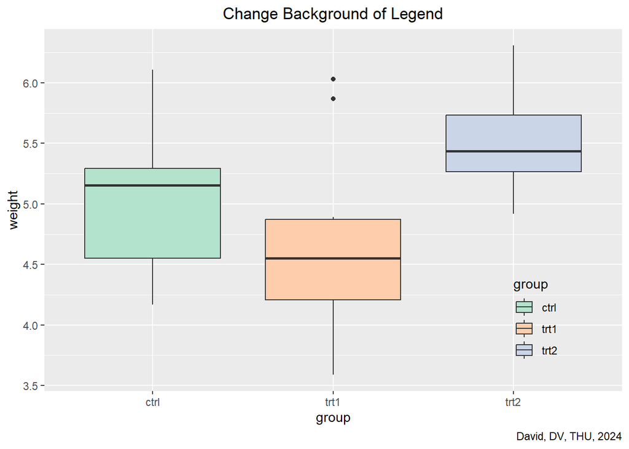

```r
ggplot(PlantGrowth, aes(x = group, y = weight, fill = group)) +
  geom_boxplot() +
  scale_fill_brewer(palette = "Pastel2") +
  ggtitle('Change Background of Legend') +
  theme(plot.title = element_text(hjust=0.5),
        legend.position = c(0.85, 0.2),
        legend.background = element_blank(),
        legend.key = element_blank()) +
  labs(caption = "David, DV, THU, 2024")
```

## 10 Change Order of Items in Legend

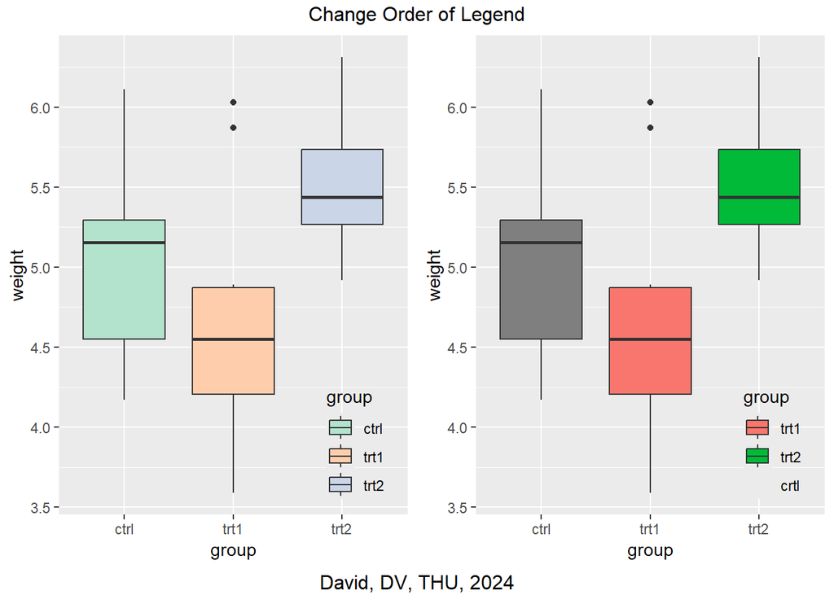

```r
d <- ggplot(PlantGrowth, aes(x = group, y = weight, fill = group)) +
  geom_boxplot() +
  theme(plot.title = element_text(hjust=0.5))

p1 <- d + scale_fill_brewer(palette = "Pastel2") +
  theme(plot.title = element_text(hjust=0.5),
        legend.position = c(.85, .15),
        legend.background = element_blank())

p2 <- d + scale_fill_discrete(limits = c('trt1', 'trt2', 'crtl')) +
  theme(plot.title = element_text(hjust=0.5),
        legend.position = c(.85, .15),
        legend.background = element_blank())

grid.arrange(p1, p2, ncol = 2, top = "Change Order of Legend", bottom = "David, DV, THU, 2024")
```

## 11 Reverse Order of the Items in Legend

`guides(fill = guide_legend(reverse = TRUE))`: To reverse the legend

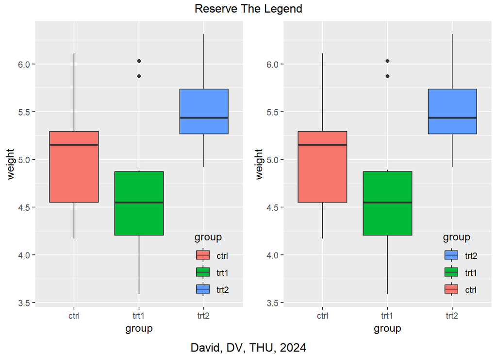

```r
d <- ggplot(PlantGrowth, aes(x = group, y = weight, fill = group)) +
  geom_boxplot() +
  theme(plot.title = element_text(hjust=0.5))

p1 <- d +
  theme(plot.title = element_text(hjust=0.5),
        legend.position = c(.85, .15),
        legend.background = element_blank())

p2 <- d + guides(fill = guide_legend(reverse = TRUE)) +
  theme(plot.title = element_text(hjust=0.5),
        legend.position = c(.85, .15),
        legend.background = element_blank())

grid.arrange(p1, p2, ncol = 2, top = "Reserve The Legend", bottom = "David, DV, THU, 2024")
```

## 12 Change Legend Title

`labs(fill = )`: To change the the legend title

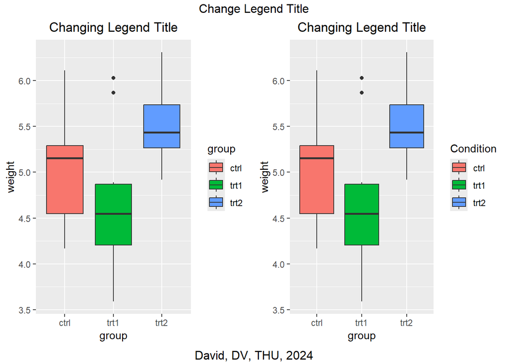

```r
p1 <- ggplot(PlantGrowth, aes(x = group, y = weight, fill = group)) +
  geom_boxplot() +
  ggtitle('Changing Legend Title') +
  theme(plot.title = element_text(hjust=0.5))

p2 <- p1 + labs(fill = 'Condition')

grid.arrange(p1, p2, ncol = 2, top = "Change Legend Title", bottom = "David, DV, THU, 2024")
```